# Making a small game with Gloss

— A tutorial

2020-11-01

Making a game, even if you have no intention of finishing it, is good practice in any programming language. While learning Haskell, before I’ve made [a terminal game](https://github.com/bergsans/tiny-haskell-and-typescript-game) but I wanted to try [making a small retro game with images for graphics](https://github.com/bergsans/glossy-haskell-game).

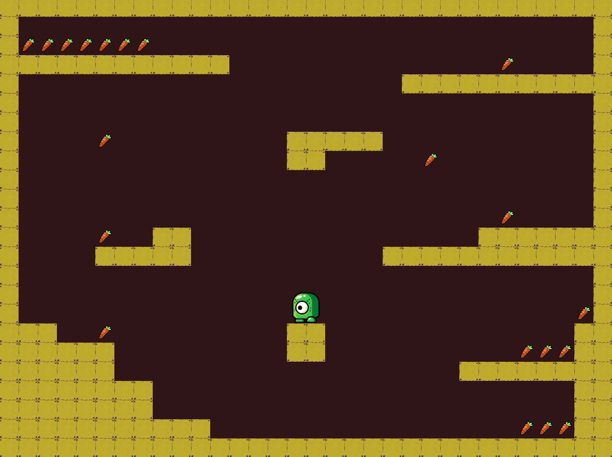

Perhaps because Haskell is not commonly used for graphics programming, there are only a few graphics libraries available. Making this game I settled with [Gloss](https://hackage.haskell.org/package/gloss).

I've found two other tutorials that may be of interest: Andrew Gibianski's [Your First Haskell Application (with Gloss)](https://andrew.gibiansky.com/blog/haskell/haskell-gloss/) and [Making a Glossy Game!](https://mmhaskell.com/blog/2019/3/25/making-a-glossy-game-part-1) on Monday Morning Haskell.

I use Stack and began by adding Gloss as a dependency to `stack.yaml`,

```
extra-deps:
- gloss-1.13.1.2
```

and added `gloss` (without a version number) to the `build-depends` of `library` and `executable`.

Note that because of the limited scope of this project (~200 lines of code), I only used the `Main.hs` of the /app folder that is created when templating a new Stack project, `stack new [your_project]`.

I used some assets. All graphics are free and were found at the [Open Game Art](https://opengameart.org/). The assets are located at such,

```
assets/
├── food.bmp
├── left1.bmp
├── left2.bmp
├── left3.bmp
├── left4.bmp
├── left5.bmp
├── left6.bmp
├── level
├── right1.bmp
├── right2.bmp
├── right3.bmp
├── right4.bmp
├── right5.bmp
├── right6.bmp
└── tile.bmp
```

`level` is a plain text file containing the level, represented by `.` for background, `*` for wall, and `%` for food (a carrot).

This is the text representation of the level:

```
********************************
*..............................*
*%%%%%%%.......................*
************..............%....*
*....................***********
*..............................*
*..............................*
*....%.........*****...........*
*..............**.....%........*
*..............................*
*..............................*
*.........................%....*
*....%..**...............*******
*....*****..........************
*..............................*
*..............................*
*.............................%*
***..%.........**.............**
******.........**..........%%%**
******..................********
********......................**
********......................**
***********................%%%**
********************************
```

This project uses one language extension, `UnicodeSyntax`, for pretty code and imports from `Gloss`,

```haskell
{-# LANGUAGE UnicodeSyntax #-}

module Main where

import Graphics.Gloss
importGraphics.Gloss.Interface.Pure.Game
```

It’s reasonable to begin by modeling the type-level data structures.

```haskell
data MoveDirection
 = East
 | West
 | None
 deriving (Eq)

data Heading
 = FacingWest
 | FacingEast
 deriving (Eq)
```

`MoveDirection` is concerned with whether the player moves West or East, or doesn’t move at all. I’ve not included a state for jumping to `MoveDirection` since I was unsure if this could be described as moving in the same sense.

`Heading` is for evaluating if the player is facing West or East. Unless you move in the opposite direction, you keep facing a direction — even when you jump.

```haskell
data GameState =
 GameState
 { position :: Point
 , direction :: MoveDirection
 , heading :: Heading
 , currentLevel :: Level
 , spriteCount :: Int
 , speedX :: Float
 , speedY :: Float
 }
```

`GameState` is a `record` holding all game-related data. `position` holds the player position using a `Float` number. `Point` is imported from the Gloss library. `direction` is linked to `MoveDirection`, and `heading` to `Heading`.

`currentLevel` is of type `Level`, and holds the level we viewed before in plain text, although read and normalized to fit the needs.

I’ll pause in describing the `GameState` and describe the types used for a level, as well as the normalization of the text representation of a level.

```haskell
type CellType = Char
type Cell = (Point, CellType)
type Level= [Cell]
```

A singular character, `Char`, is the type of the cell - the tile, if you will. I call this `CellType`. A cell as such contains a tuple holding a `Point` containing the x/y position of the cell, along with the `CellType`. A `Level` is a list containing a number of `Cell`.

When reading the file - `level` - containing the text representation, I begin the normalization by passing it as a list to `prepareData`. In `prepareData` each row and the order of succession is passed to `makeRow`. As the type signature reveals, it takes a `[String]` and returns a `Level`.

```haskell
prepareData :: [String] -> Level
prepareData rawData =
  concat [makeRow (rawData !! y) y | y <- [0..length rawData -1]]
```

`makeRow` takes a `String`, a row from the list of `[String]` passed to `prepareData`, and an `Int` — the row number — and returns a `Level` after the normalization.

The `Level` only includes ‘actual’ tiles, that is walls and carrots (we don’t need to include the ‘background’). Since Gloss centers objects using Cartesian Coordinates, and describes a `Point` using `Float`, we transform the `Int` arising from the list comprehension, and fixates its view position on the window `Display` by multiplying the size of the tile minus half the width (for the x `Point`) and half the size of the tile.

Similarly, I base y of `Point` on half the height of the window `Display` and again, half the tile size. I also inject the symbol to the second position of the tuple `Cell`.

```haskell
makeRow :: String -> Int -> Level
makeRow row y =
 [ ( ( (fromIntegral x * tileSize) - ((1024 / 2) - (tileSize / 2))
 , (fromIntegral y * tileSize) - ((768 / 2) - (tileSize / 2)))
 , row !! x)
 | x <- [0 .. length row - 1]
 , row !! x == '*' || row !! x == '%'
 ]
```

32.0 is assigned to `tileSize`,

```haskell
tileSize :: Float
tileSize = 32.0
```

```haskell
 , spriteCount :: Int
 , speedX :: Float
 , speedY :: Float
```

I use the [`Display` mode of `play`](https://hackage.haskell.org/package/gloss-1.13.1.2/docs/Graphics-Gloss.html#v:play). The Gloss documentation describes its parameters as such:

```haskell
play
:: Display                   Display mode.
-> Color                     Background color.
-> Int                       Number of simulation steps to take for each second
                             of real time.
-> world                     The initial value for world.
-> (world -> Picture)        A function to convert the world a picture.
-> (Event -> world -> world) A function to handle input events.
-> (Float -> world -> world) A function to step the world one iteration. It is
                             passed the period of time (in seconds) needing
                             to be advanced.
-> IO ()
```

Before initiating the game loop, I fetch all resources, sets an initial `GameState` and normalize the level,

```haskell
main :: IO ()
main = do
 tileImg <- loadBMP "assets/tile.bmp"
 foodImg <- loadBMP "assets/food.bmp"
 left1 <- loadBMP "assets/left1.bmp"
 left2 <- loadBMP "assets/left2.bmp"
 left3 <- loadBMP "assets/left3.bmp"
 left4 <- loadBMP "assets/left4.bmp"
 left5 <- loadBMP "assets/left5.bmp"
 left6 <- loadBMP "assets/left6.bmp"
 right1 <- loadBMP "assets/right1.bmp"
 right2 <- loadBMP "assets/right2.bmp"
 right3 <- loadBMP "assets/right3.bmp"
 right4 <- loadBMP "assets/right4.bmp"
 right5 <- loadBMP "assets/right5.bmp"
 right6 <- loadBMP "assets/right6.bmp"
 rawData <- readFile "assets/level"
 let level = prepareData $ reverse $ lines rawData
 let state =
 GameState
 { position = (0.0, 0.0)
 , direction = None
 , currentLevel = level
 , spriteCount = 0
 , heading = FacingWest
 , speedX = 0
 , speedY = (-6)
 }
```

After this I call `play`,

```haskell
play
 window
 background
 fps
 state
 (`render` [ tileImg
 , foodImg
 , left1
 , left2
 , left3
 , left4
 , left5
 , left6
 , right1
 , right2
 , right3
 , right4
 , right5
 , right6
 ])
 handleKeys
 update
```

in which `window`, `background` and `fps` are defined as,

```haskell
window :: Display
window = InWindow "Play w. Gloss" (1024, 768) (0, 0)

background :: Color
background = makeColor 0.2 0.1 0.1 1

fps :: Int
fps = 60
```

As seen in the Gloss documentation, the first four parameters - `window`, `background`, `fps`, `state` - are immutable.

```haskell
render :: GameState -> [Picture] -> Picture
render gs imgs =
 pictures
 ([drawTile cell (head imgs) (imgs !! 1) | cell <- currentLevel gs] ++
 [ translate
 (fst (position gs))
 (snd (position gs) + 10)
 (imgs !! (spriteCount gs + 2 + isRight (heading gs)))
 ])

whatImg :: Cell -> Picture -> Picture -> Picture
whatImg (_, cellType) tile food =
 if cellType == '*'
 then tile
 else food

drawTile :: Cell -> Picture -> Picture -> Picture
drawTile cell tileImg foodImg =
 uncurry translate (fst cell) (whatImg cell tileImg foodImg)

isRight :: Heading -> Int
isRight FacingEast = 6
isRight _ =0
```

The first two elements of the `[Picture]` list are the images for the wall and the carrot. I iterate the `Level` of the `GameState` using a list comprehension, passing individual cells together with two images referenced to `drawTile`.

Depending on the passed cell's `cellType` value, determined in `whatImg`, I render a wall or a carrot at the position of the `Point` of the cell.

After drawing the ‘background’, the level as such, the player is rendered at the `position` of the `GameState`. The `spriteCount` + 2 (I jump the wall and carrot in the list of images) added with the value of `isRight` determines what sprite is rendered. If the player is `FacingEast` I add 6, otherwise 0, since the list of images happens to include sprites for `FacingLeft` before `FacingEast`.

Now I continue with the next parameter of `play`, the parameter for user input.

```haskell
handleKeys :: Event -> GameState -> GameState
handleKeys (EventKey (SpecialKey KeyLeft) Down _ _) gs =
 gs {direction = West, heading = FacingWest}
handleKeys (EventKey (SpecialKey KeyRight) Down _ _) gs =
 gs {direction = East, heading = FacingEast}
handleKeys (EventKey (SpecialKey KeySpace) Down _ _) gs =
 gs
 { speedY =
 if isCollision gs (fst (position gs), snd (position gs) + speedY gs) '*'
 then 6
 else (-6)
 }
handleKeys _ gs = gs {direction =None}
```

Using pattern matching I determine between four possible states. If the user presses the Left or Right arrow, the `GameState` record is updated with a new `MoveDirection` and `Heading`. If the user presses space, I modify `speedY`, if the player is standing on firm ground. If no key is pressed, the `MoveDirection` is assigned to `None`.

In the last parameter of `play`, we make updates not relating to side-effects (such as user input in the parameter/function before).

```haskell
update :: Float -> GameState -> GameState
update _ gs =
 gs
 { speedY = checkSpeedY gs
 , speedX = checkSpeedX gs
 , position = moveY gs $ moveX (direction gs) gs
 , spriteCount = incSprite gs
 , currentLevel = checkFood gs
 }
```

As previously quoted, the `update` of `play` is ‘A function to step the world one iteration. It is passed the period of time (in seconds) needing to be advanced.’ In this project, I’ve excluded making use of the first parameter for matters of convenience.

Firstly, I check if `speedY` and `speedX` are to be updated and if so make necessary changes,

```haskell
checkSpeedY :: GameState -> Float
checkSpeedY gs
 | isCollision gs (fst (position gs), snd (position gs) + speedY gs) '*' = -3
 | speedY gs >= -6 = speedY gs - 0.1
 | otherwise = -6

checkSpeedX :: GameState -> Float
checkSpeedX gs
  | direction gs == West || direction gs == East =
if speedX gs > 5.0
  then 5.0
  else speedX gs + 0.5
  | otherwise =
if speedX gs <= 0
  then 0
  else speedX gs - 0.5

isCollision :: GameState -> Point -> CellType -> Bool
isCollision gs pnt checkType =
 any
 (\((x, y), tileType) -> tileType == checkType && isHit pnt (x, y))
 (currentLevel gs)

isHit :: Point -> Point -> Bool
isHit (b1x, b1y) (b2x, b2y) =
 (b1x - 10) < b2x + tileSize &&
 b1x +50-10> b2x && b1y < b2y + tileSize && b1y +54> b2y
```

`moveX` takes a `MoveDirection` and a `GameState` and returns a `Point`. If `MoveDirection` is either `West` or `East`, and if no collision is at hand, I modify the player position. If moving West, I multiply the `speedX` by -1, changing the direction of the movement. When `Direction` is `None`, I create the illusion of a decreasing acceleration by still moving the player, if `speedX` is greater than 0.

```haskell
moveX :: MoveDirection -> GameState -> Point
moveX East gs =
  if not (isCollision gs (fst (position gs) + speedX gs, snd (position gs)) '*')
then (fst (position gs) + speedX gs, snd (position gs))
else position gs
moveX West gs =
  if not
   (isCollision
  gs
  (fst (position gs) + speedX gs * (-1), snd (position gs))
  '*')
then (fst (position gs) + speedX gs * (-1), snd (position gs))
else position gs
moveX _ gs =
  if speedX gs > 0 &&
 not
   (isCollision
  gs
  ( fst (position gs) +
speedX gs *
(if heading gs == FacingWest
   then (-1)
   else 1)
  , snd (position gs))
  '*')
then ( fst (position gs) +
   speedX gs *
   (if heading gs == FacingWest
  then (-1)
  else 1)
 , snd (position gs))
else position gs

moveY :: GameState -> Point -> Point
moveY gs pnt =
 if not (isCollision gs (fst pnt, snd pnt + speedY gs) '*')
 then (fst pnt, snd pnt + speedY gs)
else pnt
```

`incSprite` increases the `spriteCount` by one, if not 6 (5 since we begin at 0 and have 6 sprites for each direction).

```haskell
incSprite :: GameState -> Int
incSprite gs =
 if direction gs /= None
 then if spriteCount gs == 5
 then 0
 else spriteCount gs + 1
else spriteCount gs
```

If the player is at a `Cell` holding food I filter out this element, implicitly making the list of `Level` one element shorter. If continued from 'demo' to 'real' game we would most likely increase the score at this point.

```
checkFood :: GameState -> Level
checkFood gs =
 filter
 (\cell -> not (isHit (fst cell) (position gs) && snd cell == '%'))
 (currentLevel gs)
```

Now we have the beginning of a game.

[About](https://bergsans.github.io/about) | [Archive](https://bergsans.github.io/)